# Learning Data Science Pipeline with the Titanic

Zizhen Lian

5/10/2019

### Introduction

This tutorial aims to go through the data analysis pipeline from data preparation to Machine Learning using data from the Titanic shipwreck. I choose to use this dataset because 1) that most people have heard about it and have watched the great romantic movie telling the story of it, therefore I hope this topic can arouse people’s interest; and 2) this is a competition in Kaggle.com which provides a good platform and other very intuitive tutorial using the same dataset.

With this dataset, I will try to answer the question “Can we predict the survival of a passenger on Titanic given the data?”

### 1. Data

The Kaggle competition can be found [here](https://www.kaggle.com/c/titanic/).

The dataset can be downloaded [here](https://www.kaggle.com/c/titanic/download/train.csv).

```r
# This is the path to the dataset file
csv_file = 'data/train.csv'
# Use read_csv() instead of read.csv() so that the string variable
# won't be parsed to factor yet.
tidy_data = read_csv(csv_file)
head(tidy_data)
```

| PassengerId | Survived | Pclass | Name | Sex | Age | SibSp | Parch | Ticket | Fare | Cabin | Embarked |
| --- | --- | --- | --- | --- | --- | --- | --- | --- | --- | --- | --- |
| 1 | 0 | 3 | Braund, Mr. Owen Harris | male | 22 | 1 | 0 | A/5 21171 | 7.2500 | NA | S |
| 2 | 1 | 1 | Cumings, Mrs. John Bradley (Florence Briggs Thayer) | female | 38 | 1 | 0 | PC 17599 | 71.2833 | C85 | C |
| 3 | 1 | 3 | Heikkinen, Miss. Laina | female | 26 | 0 | 0 | STON/O2. 3101282 | 7.9250 | NA | S |
| 4 | 1 | 1 | Futrelle, Mrs. Jacques Heath (Lily May Peel) | female | 35 | 1 | 0 | 113803 | 53.1000 | C123 | S |
| 5 | 0 | 3 | Allen, Mr. William Henry | male | 35 | 0 | 0 | 373450 | 8.0500 | NA | S |
| 6 | 0 | 3 | Moran, Mr. James | male | NA | 0 | 0 | 330877 | 8.4583 | NA | Q |

### 2. Exploratory Analysis

#### 2.1 Overview

Now, let’s have a general look at the data and some of its statistical properties. This will help us decide what would be the proper model and proper transmormation for the data.

```r
# Shows statistics information of the data
summary(tidy_data)
```

```
##   PassengerId       Survived          Pclass          Name
##  Min.   :  1.0   Min.   :0.0000   Min.   :1.000   Length:891
##  1st Qu.:223.5   1st Qu.:0.0000   1st Qu.:2.000   Class :character
##  Median :446.0   Median :0.0000   Median :3.000   Mode  :character
##  Mean   :446.0   Mean   :0.3838   Mean   :2.309
##  3rd Qu.:668.5   3rd Qu.:1.0000   3rd Qu.:3.000
##  Max.   :891.0   Max.   :1.0000   Max.   :3.000
##
##      Sex                 Age            SibSp           Parch
##  Length:891         Min.   : 0.42   Min.   :0.000   Min.   :0.0000
##  Class :character   1st Qu.:20.12   1st Qu.:0.000   1st Qu.:0.0000
##  Mode  :character   Median :28.00   Median :0.000   Median :0.0000
##                     Mean   :29.70   Mean   :0.523   Mean   :0.3816
##                     3rd Qu.:38.00   3rd Qu.:1.000   3rd Qu.:0.0000
##                     Max.   :80.00   Max.   :8.000   Max.   :6.0000
##                     NA's   :177
##     Ticket               Fare           Cabin             Embarked
##  Length:891         Min.   :  0.00   Length:891         Length:891
##  Class :character   1st Qu.:  7.91   Class :character   Class :character
##  Mode  :character   Median : 14.45   Mode  :character   Mode  :character
##                     Mean   : 32.20
##                     3rd Qu.: 31.00
##                     Max.   :512.33
##
```

From this summary, we find that *Name*, *Sex*, *Ticket*, *Cabin* and *Embarked* contains strings and other variables contains numbers.

- For those string variables, we may need to parse them and then use them as categorical variables (variables describe if an observed object belong to a category). We will anaylyse them latter.
- For those number variables, we need to decide if they are actually categorical variables, or real numerical variables (variables which the magnitude of the number has meaning).

#### 2.2 Variables with numbers

*Survived* is the outcome we want to predict. It is a categorical variable with 1 represents survived and 0 otherwise.

*PassengerId* is an ID number assigned for this dataset, which has no meaning and propably no use in our prediction.

*Pclass* is a number representing the passenger class, which should be a categorical variable.

*SibSp* and *Parch* represent the number of siblings and spouses, and number of parents and children respectively, which the number has useful meaning. Also for *Age* and *Fare*, these variables are intuitively numerical.

Now, let’s look at the distribution for the numerical variables.

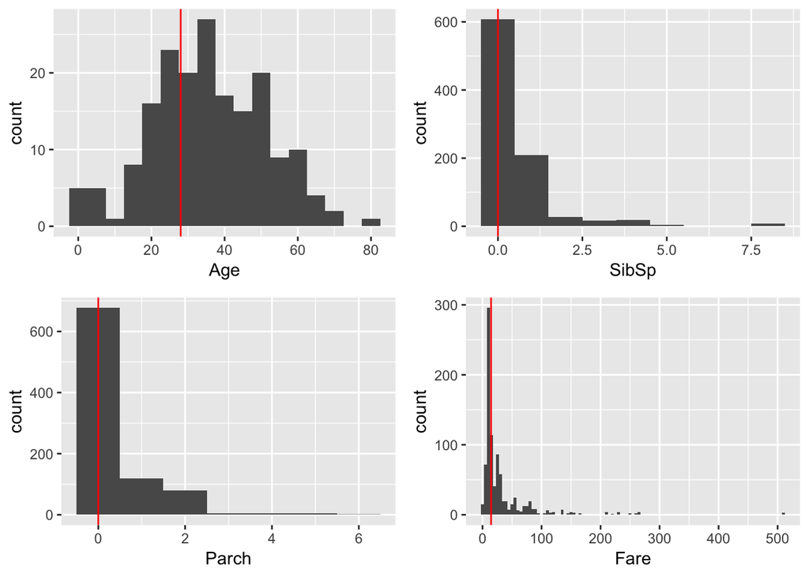

```r
# Compute the median for latter use.
Age_median = median(tidy_data$Age, na.rm = TRUE)
SibSp_median = median(tidy_data$SibSp)
Parch_median = median(tidy_data$Parch)
Fare_median = median(tidy_data$Fare)

# Making four histograms
p1 = tidy_data %>%
  drop_na() %>%  # Age has 177 missing values, so we drop them.
  ggplot(aes(x=Age)) +  # x would be the interested variable
  geom_histogram(binwidth = 5) +  # set the width of bin and draw histogram
  geom_vline(xintercept = Age_median, colour = "red")  # draw a verticle line at the median
p2 = tidy_data %>%
  ggplot(aes(x=SibSp)) +
  geom_histogram(binwidth = 1) +
  geom_vline(xintercept = SibSp_median, colour = "red")
p3 = tidy_data %>%
  ggplot(aes(x=Parch)) +
  geom_histogram(binwidth = 1) +
  geom_vline(xintercept = Parch_median, colour = "red")
p4 = tidy_data %>%
  ggplot(aes(x=Fare)) +
  geom_histogram(binwidth = 5) +
  geom_vline(xintercept = Fare_median, colour = "red")
# Put the graphs into a grid has 2 rows.
gridExtra::grid.arrange(p1,p2,p3,p4,nrow = 2)
```

The distribution of a variable with random error will have a bell-shape distribution graph. The distribution of *Age* seems good on the higher side but not so normal on the lower side, but generally fine. Also, we notice that there are 177 missing values in *Age*, since the distribution of *Age* is fine, we may try to replace those missing value with the average value. The distribution of the other three variables seem distribute more densely near 0, therefore we may consider a log transformation on them. (You can learn more about transformation [here](https://stattrek.com/regression/linear-transformation.aspx))

```r
# Selects the categorical variables from the data
cat_variables = tidy_data %>%
  select(Name, Sex, Ticket, Cabin, Embarked)
# Counts the number of distinct values in each variable
distinct_value = sapply(cat_variables, n_distinct)
# Counts the number of missing values in each variable
na_number = sapply(cat_variables, function(x) sum(is.na(x)))
# Displays a table of the numbers of distringct value and missing value for each variable
data.frame(distinct=distinct_value, NAs=na_number)
```

|  | distinct | NAs |
| --- | --- | --- |
| Name | 891 | 0 |
| Sex | 2 | 0 |
| Ticket | 681 | 0 |
| Cabin | 148 | 687 |
| Embarked | 4 | 2 |

#### 2.3 Variables with strings

*Sex* is well formed categorical variable with value “female” and “male”.

*Embarked* is also well formed. It represents the port of embarkation.(C for Cherbourg, Q for Queenstown and S for Southampton)

*Name* and *Ticket* have too many distinct values. They are not intuitively related to our question. We’ll probably not use them unless we find a proper way to categorize them.

*Cabin* should be useful because it’s related to where the cabins are. However, there are 687/891 missing values. Therefore, we have to try to guess the cabin numbers, or at least the letter representing the class of cabin.

#### 2.4 Make transformations

Therefore, we will make the following changes to our data:

- Replace missing value with average value in *Age*
- Log transformation on *SibSp*, *Parch* and *Fare*
- Feeding the categorical variables to *factor()* so the program knows it’s a categorical variable.
- Guessing the letter part of missing *Cabin* values.

```r
# Compute the average of Age
Age_mean = mean(tidy_data$Age, na.rm = TRUE)

final_data = tidy_data %>%
  select(-PassengerId, -Name, -Ticket) %>%  # Remove variables with no use
  mutate(Age=replace_na(Age,Age_mean),   # Replace missing value with average value
         SibSp=log(SibSp+1), Parch=log(Parch+1), Fare=log(Fare+1),  # Make log transformation
         Survived=factor(Survived), Pclass=factor(Pclass), Sex=factor(Sex), Embarked=factor(Embarked),  # wrap categorical variables with factor()
         Cabin=ifelse(is.na(Cabin),NA,substr(Cabin,1,1))  # Parse Cabin as the first letter of it
         )
```

This code does the first three jobs. Each value is added by 1 before log transformation because there are zero values in the three variables. It also parses the *Cabin* as a letter.

#### 2.5 Guess Cabin

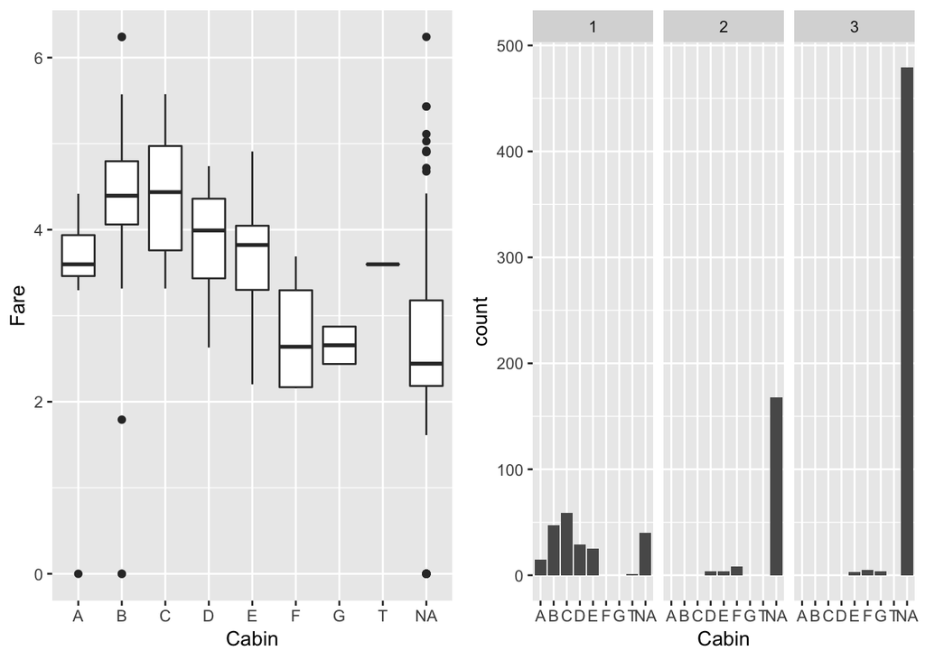

```r
# Makes a boxplot
p5 = final_data %>%
  ggplot(aes(x=Cabin, y=Fare)) +
  geom_boxplot()
# Makes histograms with count of cabins for each passenger class
p6 = final_data %>%
  ggplot(aes(x=Cabin)) +
  geom_histogram(stat="count") +
  facet_wrap( ~ Pclass, nrow = 1)
gridExtra::grid.arrange(p5,p6,nrow = 1)
```

The most intuitive way to guess a cabin value is by “calculate” it from the class of the passenger and the fare of ticket. However, the box plot above shows that there’s no clear distiction between fares for cabin B to E (You can learn more about box plot [here](http://www.physics.csbsju.edu/stats/box2.html)); the histogram above shows that the cabin has a wide spread for each class. Therefore, we can’t guess the cabin value based on only these two variables. We shouldn’t try to predict the cabin value because it will add extra error and is not good for our prediction of survival. We will remove *Cabin* from our dataset.

Then we will devide the data into an evaluation group and a training group. The evaluation group will be used at the end to evaluation the correctness of our model. The training group will be used to make estimation of parameters in our model.

```r
final_data = final_data %>%
  select(-Cabin) %>%  # remove Cabin
  drop_na()  # drop the observation with missing value still
# Sets the randomness so that the result of this analysis is reproducable
set.seed(1234)
# Randomly chooses 100 observations as evaluation group
train_ind <- sample(seq_len(nrow(final_data)), size = 100)
# Saves the evaluation group as test_data and the rest final_data
test_data <- final_data[train_ind, ]
final_data <- final_data[-train_ind, ]
```

### 3. Hypothesis Testing

In this section, we will try to answer the question “Can we predict the survival of a passenger on Titanic given the data?” with Logistic Regression and Machine Learning.(You can learn more about Logistic Regression [here](https://www.ncbi.nlm.nih.gov/pmc/articles/PMC1065119/))

#### 3.1 Build model

We build our Logistic Regression as:

$$odds(Survived)=log\frac{p(Survived)}{1-p(Survived)}=\beta_0+\beta_1Pclass+\beta_2Sex+\beta_3Age+\beta_4SibSp+\beta_5Parch+\beta_6Fare+\beta_7Embarked$$

We make a hypthesis “Yes, these variables are enough to predict survival.” In other words, “At least some of the $\beta$s will have statistically significant effect on survival”.

```r
# Makes an estimation of the logistic model
fit = glm(Survived ~ ., data=final_data, family=binomial)
tidy(fit)
```

| term | estimate | std.error | statistic | p.value |
| --- | --- | --- | --- | --- |
| (Intercept) | 2.8913796 | 0.8340491 | 3.4666781 | 0.0005269 |
| Pclass2 | -0.7914107 | 0.3404781 | -2.3244097 | 0.0201035 |
| Pclass3 | -1.9401758 | 0.3809679 | -5.0927545 | 0.0000004 |
| Sexmale | -2.7295262 | 0.2164681 | -12.6093666 | 0.0000000 |
| Age | -0.0358180 | 0.0083839 | -4.2722408 | 0.0000194 |
| SibSp | -0.7804396 | 0.2665840 | -2.9275566 | 0.0034164 |
| Parch | -0.1755235 | 0.2774547 | -0.6326203 | 0.5269816 |
| Fare | 0.3234354 | 0.1814751 | 1.7822572 | 0.0747073 |
| EmbarkedQ | 0.1900599 | 0.4057630 | 0.4684012 | 0.6394977 |
| EmbarkedS | -0.2921372 | 0.2601782 | -1.1228349 | 0.2615076 |

#### 3.2 Choose variables

We can see that *Pclass*, *Sex*, *Age*, *SibSp* has p-value smaller than 5%, which means we are 95% confident that these variable make significant effect on odds of survival. However, this doesn’t mean our hypothesis holds. We should first conduct a ovarall test on all of our variables.

```r
# Makes a global test (like F-test for linear model)
pchisq(fit$null.deviance-fit$deviance, fit$df.null-fit$df.residual, lower.tail = FALSE)
```

```
## [1] 6.315117e-74
```

The overall test also gives a very small p-value, which means we can be very confidence that our model predict the odds of survival better than just taking the mojority value.

Next, we test if removing the insignificant variables would make our model better.

```r
# Makes a partial test (like partial F-test)
fit_remove_embarked = glm(Survived ~ .-Parch-Embarked, data=final_data, family=binomial)
anova(fit_remove_embarked, fit, test = 'LRT')
```

| Resid. Df | Resid. Dev | Df | Deviance | Pr(>Chi) |
| --- | --- | --- | --- | --- |
| 782 | 682.6866 | NA | NA | NA |
| 779 | 679.3232 | 3 | 3.363433 | 0.338911 |

This test gives a very large p-value greater than 5%, therefore we are confident that the model with *Embarked* and *Parch* is no better than the one without it.

```r
tidy(fit_remove_embarked)
```

| term | estimate | std.error | statistic | p.value |
| --- | --- | --- | --- | --- |
| (Intercept) | 2.7851767 | 0.7690803 | 3.621438 | 0.0002930 |
| Pclass2 | -0.8931378 | 0.3297287 | -2.708705 | 0.0067546 |
| Pclass3 | -1.9479330 | 0.3602030 | -5.407876 | 0.0000001 |
| Sexmale | -2.7632174 | 0.2117182 | -13.051393 | 0.0000000 |
| Age | -0.0354022 | 0.0082765 | -4.277455 | 0.0000189 |
| SibSp | -0.8796008 | 0.2596209 | -3.388019 | 0.0007040 |
| Fare | 0.3042054 | 0.1629763 | 1.866562 | 0.0619627 |

The p-value of *Fare* is still greater than 5%, but since it’s close, I will leave it there.

### 4. Machine Learning

If after doing all these, you feel that you are not comfortable with the tests you can’t fully understand and the choices I made for no specific reason, that’s totally normal. I don’t like all the choices I made either. The traditional data analysis requires a lot human judgement. The good news is: We can use some other methods which requires less human inputs. They are called Machine Learning.

For demonstration, let’s see a model which is very different than the regression model, named Random Forest. (You can learn more about Random Forest [here](https://www.stat.berkeley.edu/~breiman/RandomForests/cc_home.htm))

#### 4.1 Build model

```r
# Transform Survaved to "Yes"/"No" instead of 1/0 so that the Random Forest function can work
final_data = final_data %>%
  mutate(Survived=ifelse(Survived==1,'Yes', 'No'))
# Makes an estimation of the Random Forest model
rf_fit <- train(Survived~.-Sex-Pclass-Embarked,
                  data=final_data,
                  method = "rf",
                  ntree = 10,  # Only parameter, number of trees in each iteration.
                  trControl = trainControl(classProbs=TRUE)
                )
```

The only human input here is the parameter *ntree*, which represents number of trees in each iteration of Random Forest.

#### 4.2 Evaluation

Finally, let’s make prediction with the two models and compare there accuracy.

```r
# Predicts using Random Forest model we got and transforms the result back to 1/0 form
rf_predict = ifelse(predict(rf_fit, test_data) == "Yes", 1, 0)
# Predicts using Logistic Regression model. The result is one if the odds > 1
regression_predict = ifelse(predict(fit_remove_embarked, test_data) > 1, 1, 0)

data.frame(Random_Forest=sum(rf_predict==test_data$Survived),
           Regression=sum(regression_predict==test_data$Survived))
```

| Random_Forest | Regression |
| --- | --- |
| 64 | 74 |

The Logistic Regression model has higher accuracy, but Random Forest is also not that far off.

### Conclusion

What do we learn from doing all these? First of all, we can confidently answer our original question:
$$\mbox{Yes, we can predict the survival of a passenger with at least 70% accuracy using this dataset}$$
Secondly, we see how several lines of codes can make a Machine Learning model with close performance than a Regression model we get from careful analysis. In nowadays internet era, Machine Learning can help people make model with good performance in a fast speed. Everyone who’s interested in data should learn about it.